# Individual Rides Made in a Bike-sharing System

## Investigation Overview

This study investigates when most trip were performed in terms of duration and day of the week. Additionally, it investigates how features like age group and gender depends on if a user is a subscriber or customer.

## Dataset Overview

The dataset consisted of 183412 ford gobike entries and 16 features. After preliminary wrangling, the entries were reduced to 174952 while the features to 12.

### Distribution of age

From this plot, it was observed that the age distribution of the riders is skewed to the right, that is, positively skewed. This indicate that the mean of their ages is greater than the median and mode.

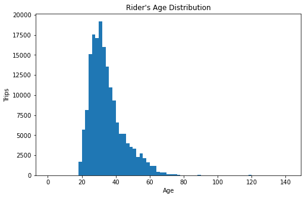

### Plot showing the age group with the highest trips

This plot shows that most of trips were performed by users within the age group of 20-29 and 30-39. However, users within the age group of 70-79 and 80-141 rarely performed any trip.

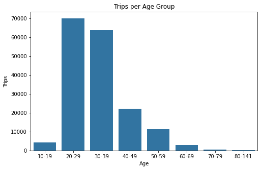

### Distribution of days with the highest trips

This graph shows that most trips were performed on thursday, followed by tuesday. Additionally, the numbers of trips performed on saturday and sunday were almost thesame.

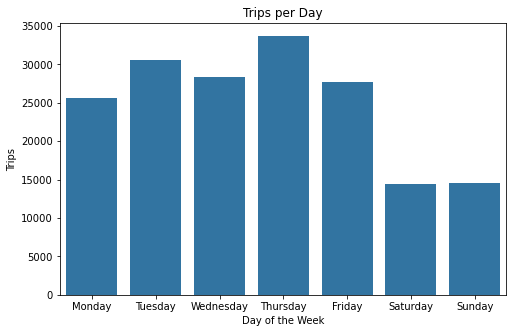

### Visualing the users' gender based on age group

This plot gave more insight on how the rider's ages and their gender are related. It was observed that most trips were performed by males who were between the age group between of 20-29 and 30-39.

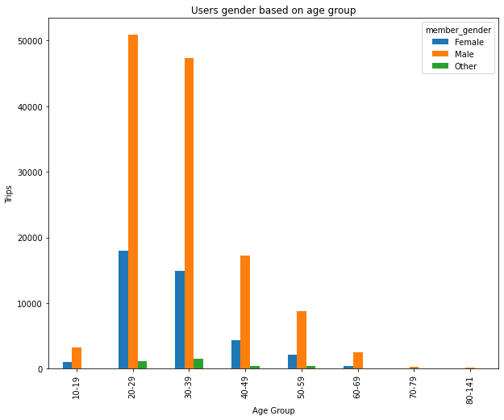

### Relationship between gender and user type

The heatmap revealed that most riders were male and they were subscribers. Additionally, female subscribers were three times greater than male customers.

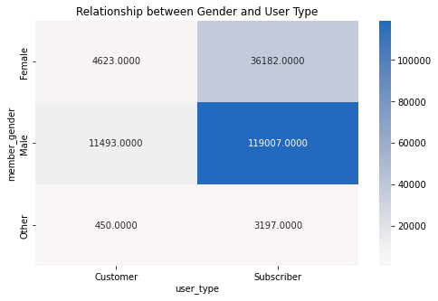

### Relationship between age group, gender, trip duration

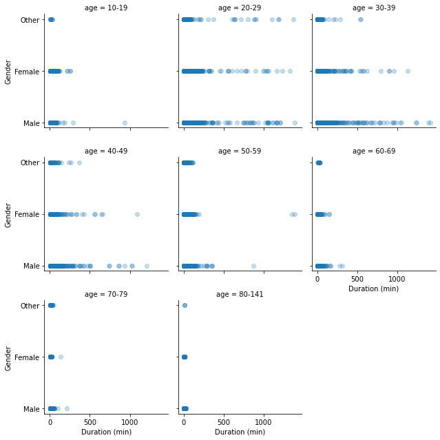

[output not shown]